# Case_Study_Group_25

Analysis of defective registered diesel-engine vehicles

16-09-2022

# 1 Include Packages

```r
if (!require(install.load)){
  install.packages("install.load")
}
library(install.load)
install_load("tidyverse", "geosphere", "here")
print("Successfully loaded all packages!")
```

```
## [1] "Successfully loaded all packages!"
```

# 2 Importing the data

Our approach divided into several step in order to select the relevant data sets to answer our analysis question:  
1. Step: We read our problem statement to obtain a deeper understanding of the task at hand  
2. Step: After the initial read through, we highlighted import variable, which will affect our analysis:

```
* Problematic vehicle type => Type 11
* Installed engine => K1DI1
* Production date >= 21.09.2010 & <= 04.09.2012
* User-defined radius of max. 80km around Berlin for registered cars
* Defective vehicle = Each individual part OR component OR entire vehicle is marked as defective
```

3. Step: Obtaining an initial local overview of the provided files to get familiar with the file structure  
4. Step: Selecting the relevant data sets for our analysis:

```
* Data tables
    + Fahrzeug_OEM1_Typ11.csv => Problematic vehicle type
    + Komponente_K1DI1.csv => Installed engine
    + Einzelteil_T01.txt => Individual part of installed engine
    + Einzelteil_T02.txt => Individual part of installed engine
    + Einzelteil_T05.csv => Individual part of installed engine
    + Einzelteil_T06.csv => Individual part of installed engine
    + Zulassungen_alle_Fahrzeuge.csv => All registered cars
    + Geodaten_Gemeinden_v1.2_2017-08-22_TrR.csv => Lat & Long for the regions in which the cars where registered

* Junction tables
    + Bestandteile_Fahrzeuge_OEM_Typ11.csv => Problematic vehicle type
    + Bestandteile_Komponente_K1DI1.csv => Installed engine
```

5. Step: Identifying the connections between the different tables + possible data size optimization based on the highlighted variable and relationships

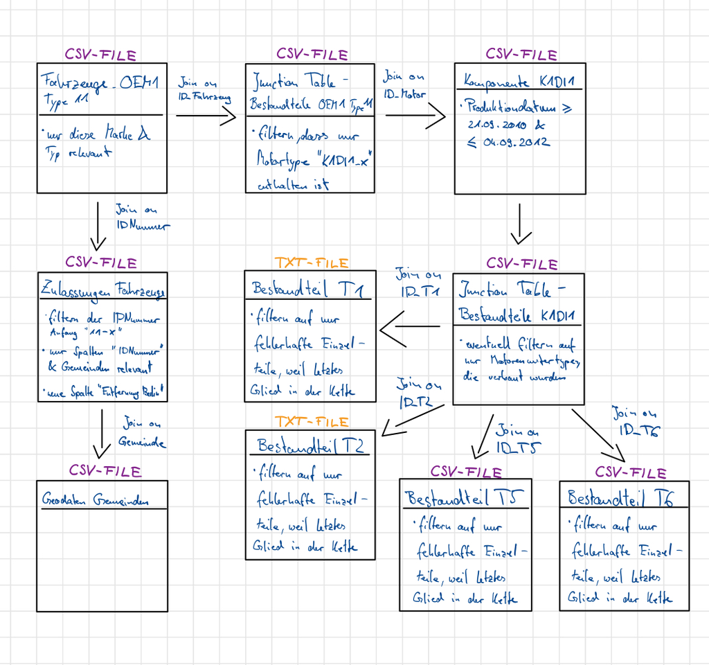

6. Step: Since we are only working with flat files (CSV & TXT), we load the identified data sets with the R package “readr” (included in the R package “tidyverse”) to increase speed and efficiency

```r
# Relevant CSV file for the identified vehicle type
rval_vehicle_data <- read_csv(here("Data", "Fahrzeug", "Fahrzeuge_OEM1_Typ11.csv"), col_names= TRUE, trim_ws= TRUE) %>%
  select("ID_Fahrzeug", "Fehlerhaft")

# Junction table for relationship between vehicle and component
# Based on problem statement, table size and number of dimensions was reduced to save memory space
junction_table_vehicle <- read_csv2(here("Data", "Fahrzeug", "Bestandteile_Fahrzeuge_OEM1_Typ11.csv"), col_names=TRUE, trim_ws= TRUE) %>%
  select("ID_Motor", "ID_Fahrzeug") %>%
  filter(str_detect(ID_Motor, "^K1DI1"))

# Relevant CSV file for the identified component type
# Structure of the table needed to be adjusted since each unique column was repeated after a certain amount of observations
# Each row included one complete observation and NAs for remaining columns
# In addition, only the specified time range was selected
rval_component_data <- read_csv(here("Data", "Komponente", "Komponente_K1DI1.csv"), col_names=TRUE, trim_ws= TRUE) %>%
  mutate(ID_Motor = coalesce(ID_Motor.x, ID_Motor.y, ID_Motor)) %>%
  mutate(Produktionsdatum = coalesce(Produktionsdatum.x, Produktionsdatum.y, Produktionsdatum)) %>%
  mutate(Herstellernummer = coalesce(Herstellernummer.x, Herstellernummer.y, Herstellernummer)) %>%
  mutate(Werksnummer = coalesce(Werksnummer.x, Werksnummer.y, Werksnummer)) %>%
  mutate(Fehlerhaft = coalesce(Fehlerhaft.x, Fehlerhaft.y, Fehlerhaft)) %>%
  mutate(Fehlerhaft_Datum = coalesce(Fehlerhaft_Datum.x, Fehlerhaft_Datum.y, Fehlerhaft_Datum)) %>%
  mutate(Fehlerhaft_Fahrleistung = coalesce(Fehlerhaft_Fahrleistung.x, Fehlerhaft_Fahrleistung.y, Fehlerhaft_Fahrleistung)) %>%
  select("ID_Motor", "Produktionsdatum", "Fehlerhaft") %>%
  filter(Produktionsdatum >= "2010-09-21" & Produktionsdatum <= "2012-09-04")

# Junction table for relationship between component and individual part
junction_table_component <- read_csv2(here("Data", "Komponente", "Bestandteile_Komponente_K1DI1.csv"), col_names=TRUE, trim_ws= TRUE) %>%
  select(-c(...1))

# Relevant files for individual parts

txt_t1 <- readLines(here("Data", "Einzelteil", "Einzelteil_T01.txt"))
txt_t1 <- paste('"ID" | |', txt_t1)
txtNew_t1 <- gsub(x = txt_t1, pattern = "\\s\\|\\s\\|\\s", replacement = ",")
rm(txt_t1)
txtNew_t1 <- gsub(x = txtNew_t1, pattern = "\\s", replacement = "\n")
txtNew_t1 <- substring(txtNew_t1, 1, nchar(txtNew_t1)-1)

rval_part_t1 <- read_delim(I(txtNew_t1), delim = ",", trim_ws = TRUE)
rval_part_t1 <- select(rval_part_t1, -1)
rval_part_t1 <- rval_part_t1 %>%
                  select("ID_T01.x", "ID_T01.y", "ID_T01", "Fehlerhaft.x", "Fehlerhaft.y", "Fehlerhaft") %>%
                  mutate(ID_T01 = coalesce(ID_T01.x, ID_T01.y, ID_T01)) %>%
                  mutate(Fehlerhaft = coalesce(Fehlerhaft.x, Fehlerhaft.y, Fehlerhaft)) %>%
                  select("ID_T01", "Fehlerhaft") %>%
                  filter(Fehlerhaft == 1)

rm(txtNew_t1)

txt_t2 <- readLines(here("Data", "Einzelteil", "Einzelteil_T02.txt"))
txtNew_t2 <- gsub(x = txt_t2, pattern = "\t\"[0-9]+\"\\s", replacement = "\n")
txtNewe_t2 <- gsub(x = txtNew_t2, pattern = "\n\\s", replacement = "\n")
txtNewer_t2 <- gsub(x = txtNewe_t2, pattern = "[ \t]+", replacement = ",")
txtNewer_t2 <- substring(txtNewer_t2, 1, nchar(txtNewer_t2)-1)

rval_part_t2 <- read_delim(I(txtNewer_t2), delim = ",", trim_ws = TRUE) %>%
  select("ID_T02.x", "ID_T02.y", "Fehlerhaft.x", "Fehlerhaft.y") %>%
  mutate(ID_T02 = coalesce(ID_T02.x, ID_T02.y)) %>%
  mutate(Fehlerhaft = coalesce(Fehlerhaft.x, Fehlerhaft.y)) %>%
  select("ID_T02", "Fehlerhaft") %>%
  filter(Fehlerhaft == 1)

rm(txt_t2, txtNew_t2, txtNewe_t2, txtNewer_t2)

rval_part_t5 <- read_csv(here("Data", "Einzelteil", "Einzelteil_T05.csv"), col_names=TRUE, trim_ws= TRUE) %>%
  select("ID_T05.x", "ID_T05.y", "Fehlerhaft.x", "Fehlerhaft.y") %>%
  mutate(ID_T05 = coalesce(ID_T05.x, ID_T05.y)) %>%
  mutate(Fehlerhaft = coalesce(Fehlerhaft.x, Fehlerhaft.y)) %>%
  select("ID_T05", "Fehlerhaft") %>%
  filter(Fehlerhaft == 1)

rval_part_t6 <- read_csv(here("Data", "Einzelteil", "Einzelteil_T06.csv"), col_names=TRUE, trim_ws= TRUE) %>%
  select("ID_T06", "Fehlerhaft") %>%
  filter(Fehlerhaft == 1)

# Relevant file for car registration
# Can filter the data to only include registrations for the vehicle type 11 & which were registered at least at the same day as the engine was produced
rval_car_registrations <- read_csv2(here("Data", "Zulassungen", "Zulassungen_alle_Fahrzeuge.csv"), col_names=TRUE, trim_ws= TRUE) %>%
  select(-c(...1, Zulassung)) %>%
  filter(str_detect(IDNummer, "^11-"))

# Relevant file for geographical data
rval_geo_data <- read_csv2(here("Data", "Geodaten", "Geodaten_Gemeinden_v1.2_2017-08-22_TrR.csv"), col_names=TRUE, trim_ws= TRUE) %>%
  select(-c(...1, X, Postleitzahl))

# List of all variable to increase the efficiency for checking missing values
var_list <- list(vehicle = rval_vehicle_data,
                 junction_vehicle = junction_table_vehicle,
                 junction_component = junction_table_component,
                 components = rval_component_data,
                 parts_t1 = rval_part_t1,
                 parts_t2 = rval_part_t2,
                 parts_t5 = rval_part_t5,
                 parts_t6 = rval_part_t6,
                 geo_data = rval_geo_data,
                 car_registrations = rval_car_registrations)

rm(rval_vehicle_data,
   junction_table_vehicle,
   rval_component_data,
   junction_table_component,
   rval_part_t1,
   rval_part_t2,
   rval_part_t5,
   rval_part_t6,
   rval_geo_data,
   rval_car_registrations)
```